# intrinsicFRP: An R Package for Factor Model Asset Pricing

18 September 2023

# Summary

`intrinsicFRP` is a lightweight R package providing an efficient implementation of methods from (Bryzgalova et al. 2025) for estimating and testing asset pricing models based on tradable factor risk premia. These risk premia are given by the negative factor covariance with the Stochastic Discount Factor projected on returns. They are robust to model misspecification, asset repackaging and to the presence of factors that are weakly correlated with returns (called weak factors from here on).

A simple estimator for tradable factor risk premia, replacing population moments with empirical ones, remains consistent and asymptotically Gaussian, even for weak factors having correlations with returns that vanish at a rate of $1/T^\alpha$, where $T$ is the sample size (for $\alpha>1/2$). For slowly vanishing weak factors ($1/T^{1/2}$), the simple exhibits a bias term, but this doesn’t affect other factor risk premia.

(Bryzgalova et al. 2025) further introduces an Oracle estimator that enhances the simple one by using adaptively weighted lasso penalization to consistently remove problematic weak factors. It consistently removes the risk premium of any weak factor and possesses an efficient asymptotic Gaussian distribution for the remaining factors.

These properties of the simple and Oracle tradable factor risk premia estimators are noteworthy compared to commonly used estimators in the literature, like the Fama-MacBeth (Fama and MacBeth 1973) and misspecification-robust (Kan, Robotti, and Shanken 2013) estimators. These latter estimators, even in standard settings, may exhibit non-Gaussian asymptotic distributions and may not converge to zero for weak factors, as shown by in (Kan and Zhang 1999), (Kleibergen 2009), and (Gospodinov, Kan, and Robotti 2014).

In Figure 1, the misspecification-robust risk premium on the useless factor has the highest absolute value, with a wide 95% confidence interval. This reflects the poor statistical properties of the misspecification-robust estimator in the presence of weak factors. Conversely, the point estimate of the tradable risk premium on the useless factor remains close to zero, with a more concentrated 95% confidence interval. Finally, the point estimate of the Oracle tradable risk premium estimator on the useless factor is exactly zero, showcasing its variable selection capabilities.

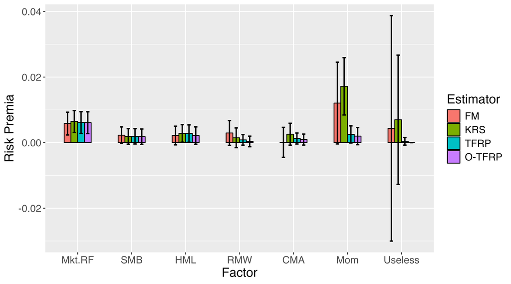

# Statement of need

The R package `intrinsicFRP` is helpful for researchers and practitioners in finance due to the following pressing issues:

- Lack of Existing Code for Cutting-Edge Methods: The field of financial econometrics is rapidly advancing. However, one major challenge is the absence of readily available code, especially in R, to implement the state-of-the-art methods. The `intrinsicFRP` package directly addresses this gap by providing a comprehensive and efficient implementation of the novel techniques established in (Bryzgalova et al. 2025).
- Dependency on Closed-Source Software: Historically, legacy code for factor models in finance has predominantly been written in proprietary programming languages like MATLAB. This dependence on closed-source software poses significant limitations, hindering accessibility, transparency, and collaboration within the research community. The `intrinsicFRP` R package is an open-source alternative that allows researchers to perform factor risk premia estimation and testing in a familiar, open environment.

By addressing these two key issues, the `intrinsicFRP` R package empowers researchers and practitioners in finance to:

- Readily apply the methods developed in (Bryzgalova et al. 2025) to their own research, facilitating the exploration of new avenues in asset pricing models and risk premia estimation.
- Promote open-source science software and overcome MATLAB dependencies, thereby improving transparency and reproducibility of research in the Asset Pricing and related fields. By eliminating software constraints, we aim to facilitate access to advanced methods for finance researchers and practitioners, fostering collaboration among researchers and enabling the wider financial community to further develop and validate the suggested approaches.

# Features

The `intrinsicFRP` R package includes two datasets sourced from the [Kenneth French data library](https://mba.tuck.dartmouth.edu/pages/faculty/ken.french/data_library.html):

- `returns`: Monthly observations from January 1970 to December 2021, containing excess returns data for 25 Size/Book-to-Market portfolios and 17 industry portfolios.
- `factors`: Monthly observations from January 1970 to December 2021, containing data for the Fama-French 5 factors and the momentum factor.

Additionally, `intrinsicFRP` implements methods for computing point estimates and standard errors for the simple and Oracle tradable factor risk premia estimators, as well as the Fama-MacBeth and misspecification-robust factor risk premia. The package also provides functions for conducting model identification tests developed in (Kleibergen and Paap 2006) and their bootstrap improvement in (Chen and Fang 2019), along with the model misspecification test from (Hansen and Jagannathan 1997). The key functions in `intrinsicFRP` include:

- `TFRP()`: Computes tradable factor risk premia from data on factors and test asset excess returns. Optionally it computes robust standard errors accounting for heteroskedasticity and autocorrelation.
- `OracleTFRP()`: Computes optimal Oracle tradable factor risk premia using data on factors and test asset excess returns. Tuning is performed through Generalized Cross Validation (GCV), Cross Validation (CV), or Rolling Validation (RV). Robust standard errors can also be computed.
- `FRP()`: Computes Fama MachBeth (1973) or misspecification-robust factor risk premia following Kan Robotti Shanken (2013) based on data from factors and test asset excess returns. Robust standard errors can also be computed.
- `ChenFang2019BetaRankTest()`: Conducts an asset pricing model identification test using data on factors and test asset excess returns. This test combines rank tests from (Chen and Fang 2019) and (Kleibergen and Paap 2006) on the matrix of regression coefficients of test asset excess returns against risk factors.
- `HJMisspecificationTest()`: Performs an asset pricing model misspecification test using data on factors and test asset excess returns. It utilizes the Hansen-Jagannatan test as described in (Hansen and Jagannathan 1997).

To optimize computational performance, all these methods are implemented in C++ and make use of the Armadillo (Sanderson and Curtin 2016) library for efficient linear algebra calculations. However, for user convenience, the package’s interface is entirely implemented in R.

# Dependencies

The `intrinsicFRP` library is a lightweight package with minimal dependencies, including:

- `Rcpp` (Eddelbuettel and Balamuta 2018) and `RcppArmadillo` (Eddelbuettel and Sanderson 2014): They facilitate seamless integration between R, C++, and the armadillo C++ library.
- `graphics`: Provides R functions for creating basic graphics.
- `stats`: Offers R functions for performing statistical calculations and random number generation.

# References

Bryzgalova, Svetlana, Alberto Quaini, Fabio Trojani, and Ming Yuan. 2025. “Tradable Factor Risk Premia and Oracle Tests of Asset Pricing Models.” *Swiss Finance Institute Research Paper*, no. 23-81. https://doi.org/10.2139/ssrn.4574683.

Chen, Qihui, and Zheng Fang. 2019. “Improved Inference on the Rank of a Matrix.” *Quantitative Economics* 10 (4): 1787–1824. https://doi.org/10.2139/ssrn.3177681.

Eddelbuettel, Dirk, and James Joseph Balamuta. 2018. “Extending r with c++: A Brief Introduction to Rcpp.” *The American Statistician* 72 (1): 28–36. https://doi.org/10.1080/00031305.2017.1375990.

Eddelbuettel, Dirk, and Conrad Sanderson. 2014. “RcppArmadillo: Accelerating r with High-Performance c++ Linear Algebra.” *Computational Statistics & Data Analysis* 71: 1054–63. https://doi.org/10.1016/j.csda.2013.02.005.

Fama, Eugene F, and James D MacBeth. 1973. “Risk, Return, and Equilibrium: Empirical Tests.” *Journal of Political Economy* 81 (3): 607–36. https://doi.org/10.1086/260061.

Gospodinov, Nikolay, Raymond Kan, and Cesare Robotti. 2014. “Misspecification-Robust Inference in Linear Asset-Pricing Models with Irrelevant Risk Factors.” *The Review of Financial Studies* 27 (7): 2139–70. https://doi.org/10.2139/ssrn.2579821.

Hansen, Lars Peter, and Ravi Jagannathan. 1997. “Assessing Specification Errors in Stochastic Discount Factor Models.” *The Journal of Finance* 52 (2): 557–90. https://doi.org/10.3386/t0153.

Kan, Raymond, Cesare Robotti, and Jay Shanken. 2013. “Pricing Model Performance and the Two-Pass Cross-Sectional Regression Methodology.” *The Journal of Finance* 68 (6): 2617–49. https://doi.org/10.3386/w15047.

Kan, Raymond, and Chu Zhang. 1999. “Two-Pass Tests of Asset Pricing Models with Useless Factors.” *The Journal of Finance* 54 (1): 203–35. https://doi.org/10.1111/0022-1082.00102.

Kleibergen, Frank. 2009. “Tests of Risk Premia in Linear Factor Models.” *Journal of Econometrics* 149 (2): 149–73. https://doi.org/10.1016/j.jeconom.2009.01.013.

Kleibergen, Frank, and Richard Paap. 2006. “Generalized Reduced Rank Tests Using the Singular Value Decomposition.” *Journal of Econometrics* 133 (1): 97–126. https://doi.org/10.2139/ssrn.373420.

Sanderson, Conrad, and Ryan Curtin. 2016. “Armadillo: A Template-Based c++ Library for Linear Algebra.” *Journal of Open Source Software* 1 (2): 26. https://doi.org/10.21105/joss.00026.